# World Happiness Report Data

# Introduction

Do you love where you live and are shocked why everyone just doesn’t live in your country? Or maybe you absolutely hate where you live and don’t understand why anyone would move to your country. Either way, you can get your questions answered through this R analysis! We will perform a datascience pipeline on the World Happiness Report. The World Happiness Report is a dataset released by the United Nations anually that rank’s countries based on happiness levels. The report contains a Happiness Score that is then used to determine a countries rank relative to other country’s scores. There are different metrics are juxtaposed with the score and I was curious to see which one metric could be singled out (if at all) to be the best predictor of a country’s score.

To learn more about the World Happiness Report visit : http://worldhappiness.report/ed/2018/

# Required Libraries

Replication of analysis requires RStudio version 3.4.3 and the following libraries.

```r
require(rvest)
require(magrittr)
require(dplyr)
require(tidyr)
require(ggplot2)
require(tree)
```

# 1. Gather Data

Welcome to the first step in the data pipeline! We can’t perform any operations on our data or conduct any analysis until we have a dataset to work with. Because we are strong, independent data scientists, we do not require a CSV file to be provided beforehand. Instead, we obtain our data through a process called HTML scraping. HTML scraping involves using pre-existing html files in webpages to extract the data we are interested in.

```r
url <- "https://en.wikipedia.org/wiki/World_Happiness_Report"
df_2018 <- read_html(url) %>%
        #look for html node table
        html_nodes("table") %>%
        #extract 5th occurence
        extract2(5) %>%
        html_table() %>%
        as.data.frame()
as_tibble(df_2018)
```

```
## # A tibble: 156 x 9
##    `Overall Rank` Country     Score `GDP per capita` `Social support`
##             <int> <chr>       <dbl>            <dbl>            <dbl>
##  1              1 Denmark      7.63             1.30             1.59
##  2              2 Norway       7.59             1.46             1.58
##  3              3 Finland      7.56             1.35             1.59
##  4              4 Iceland      7.50             1.34             1.64
##  5              5 Switzerland  7.49             1.42             1.55
##  6              6 Netherlands  7.44             1.36             1.49
##  7              7 Canada       7.33             1.33             1.53
##  8              8 New Zealand  7.32             1.27             1.60
##  9              9 Sweden       7.31             1.36             1.50
## 10             10 Australia    7.27             1.34             1.57
## # ... with 146 more rows, and 4 more variables: `Healthy life
## #   expectancy` <dbl>, `Freedom to make life choices` <dbl>,
## #   Generosity <dbl>, `Perceptions of corruption` <chr>
```

Hey that’s a pretty good looking data frame! However, looks can be decieving and we still need to tidy up this frame.

# 2. Tidy Data

Tidying data is a process where data scientists structures a dataset to make it easier to perform analysis and operations on the data. Hidden in this data frame is a single NA, or missing entry for our Perceptions of Corruption column for the entity identifying as the United Arab Emirates. Unfortunately, I have no friends in the United Nations and so I never got an answer to why this entry was missing, but that’s okay, we will continue on using plan B, imputing data. Imputing data requires us to insert a value for the missing entry in an unbiased way. We will accomplish this by calculating the mean of Perceptions of Corruption and inserting that value as our missing data. THis will ensure the central tendency of the data is the same.

Another checkpoint for tidy data is ensuring that column types match their values. Everything is dandy up until Perceptions of Corruption. This column is encoded as “” or string which mean’s all of its values will also be a string. This is detrimental to our methods because we have to compute the mean of the column to use in imputing for our missing data and the mean of strings makes no sense. Let’s convert every value in the column to a double.

```r
df_2018 <-
  df_2018 %>%
  #rename columns so that they are easier on the eye
  set_colnames(c("Rank", "Country","Score","GDP", "Social_Support","Health_Expectancy","Freedom","Generosity", "Perceptions_Of_Corruption"))
  #type convert from character vector to numeric double
  df_2018$Perceptions_Of_Corruption <- as.numeric(as.character(df_2018$Perceptions_Of_Corruption))
  #impute mean value for missing entry
  df_2018[is.na(df_2018)] <- mean(df_2018$Perceptions_Of_Corruption, na.rm = TRUE)
as_tibble(df_2018)
```

```
## # A tibble: 156 x 9
##     Rank Country     Score   GDP Social_Support Health_Expectancy Freedom
##    <int> <chr>       <dbl> <dbl>          <dbl>             <dbl>   <dbl>
##  1     1 Denmark      7.63  1.30           1.59             0.874   0.681
##  2     2 Norway       7.59  1.46           1.58             0.861   0.686
##  3     3 Finland      7.56  1.35           1.59             0.868   0.683
##  4     4 Iceland      7.50  1.34           1.64             0.914   0.677
##  5     5 Switzerland  7.49  1.42           1.55             0.927   0.660
##  6     6 Netherlands  7.44  1.36           1.49             0.878   0.638
##  7     7 Canada       7.33  1.33           1.53             0.896   0.653
##  8     8 New Zealand  7.32  1.27           1.60             0.876   0.669
##  9     9 Sweden       7.31  1.36           1.50             0.913   0.659
## 10    10 Australia    7.27  1.34           1.57             0.910   0.647
## # ... with 146 more rows, and 2 more variables: Generosity <dbl>,
## #   Perceptions_Of_Corruption <dbl>
```

# Exploratory Data Analysis

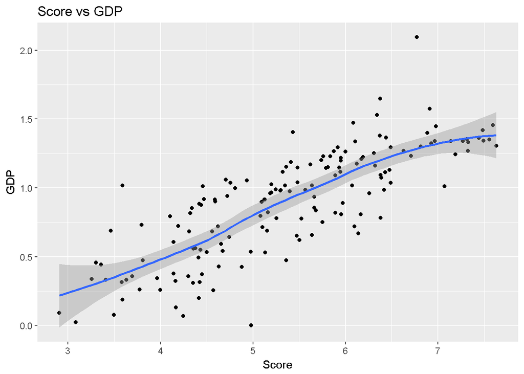

```r
df_2018 %>% ggplot(aes(x= Score, y = GDP)) + geom_point() + geom_smooth(lm = loess) + labs(title = "Score vs GDP")
```

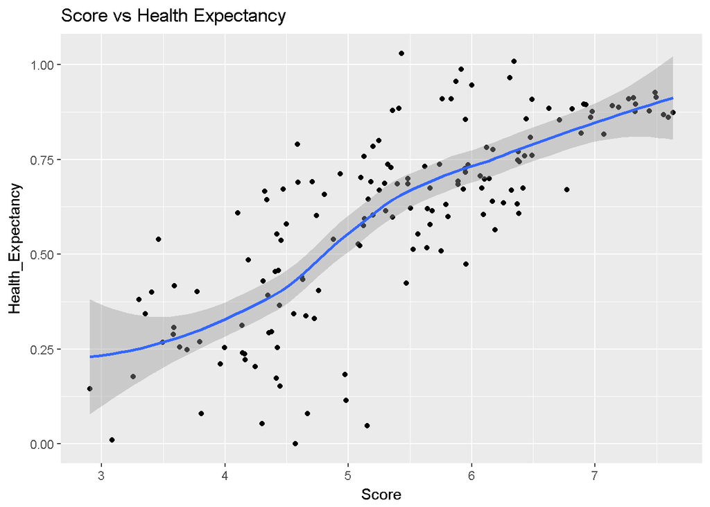

```r
df_2018 %>% ggplot(aes(x= Score, y = Health_Expectancy)) + geom_point() + geom_smooth(lm = loess) + labs(title = "Score vs Health Expectancy")
```

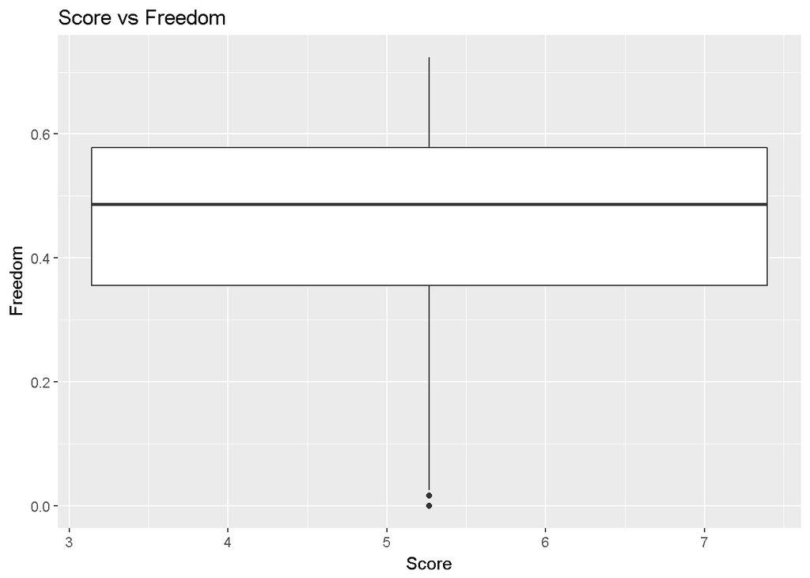

```r
df_2018 %>% ggplot(aes(x= Score, y = Freedom)) + geom_boxplot() + labs(title = "Score vs Freedom")
```

# Machine Learning

```r
fit <- lm(Score ~ 1 + GDP+Social_Support+Health_Expectancy+ Health_Expectancy+Freedom+Generosity+Perceptions_Of_Corruption, data = df_2018)
broom::tidy(fit) %>% knitr::kable()
```

| term | estimate | std.error | statistic | p.value |
| --- | --- | --- | --- | --- |
| (Intercept) | 1.8803969 | 0.1939790 | 9.693818 | 0.0000000 |
| GDP | 1.1026589 | 0.2092118 | 5.270539 | 0.0000005 |
| Social_Support | 0.9977967 | 0.2013778 | 4.954850 | 0.0000019 |
| Health_Expectancy | 0.8055928 | 0.3290109 | 2.448529 | 0.0155047 |
| Freedom | 1.4069590 | 0.3183240 | 4.419897 | 0.0000189 |
| Generosity | 0.5587707 | 0.4703165 | 1.188074 | 0.2366946 |
| Perceptions_Of_Corruption | 0.7160442 | 0.5263550 | 1.360383 | 0.1757634 |